# Chapter 6: Modeling Random Events

COR 142 C

Author

Dr. Kao

## Section 6.1. Probability Distributions

**NoteProbability Distribution (PDF)**

A probability distribution is a tool, in the form of a table or a graph, that tells us

1. **All possible outcomes of a random experiment.**
2. **The probability of each outcome.**

**NoteFeatures of a Probability Distribution**

1. All $P(X)$ must be between **0** and **1**.
2. The sum of all $P(X)$ values must equal **1**.

**NoteDiscrete and Continuous Variables**

- **Discrete variable**: Numerical values that you can **list** or **count**.
- **Continuous variable**: Numerical values that cannot be **listed or counted** because they occur over a continuous range of values.

**TipExample 6.1.1.**

**Question**

Determine the variable type.

1. Number of siblings you have
2. Height of basketball players
3. Number of cars owned by a household
4. Number of pets owned by a student
5. Temperature of St. Augustine on January 1st, 2000
6. Wait time in a doctor’s office

**Answer**

a. Discrete  
b. Continuous  
c. Discrete  
d. Discrete  
e. Continuous  
f. Continuous

**NoteDiscrete Variables**

**NoteContinuous Variables**

The graph of a continuous probability distribution is called a **density curve** or **probability density function*** (**pdf**). These graphs have an **area** under the curve that must equal to 1. Therefore, **the area under the curve represents the probability.**

The plot below illustrates the probability $P(X \geqslant x_1)$ or $P(X > x_1)$ for a normal curve.

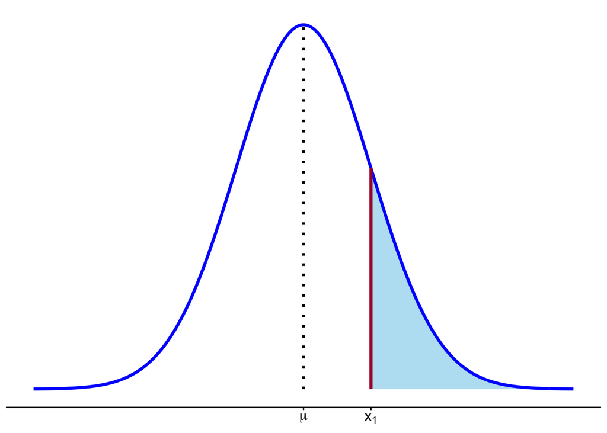

The plot below illustrates the probability $P(X \leqslant x_1)$ or $P(X < x_1)$ for a normal curve.

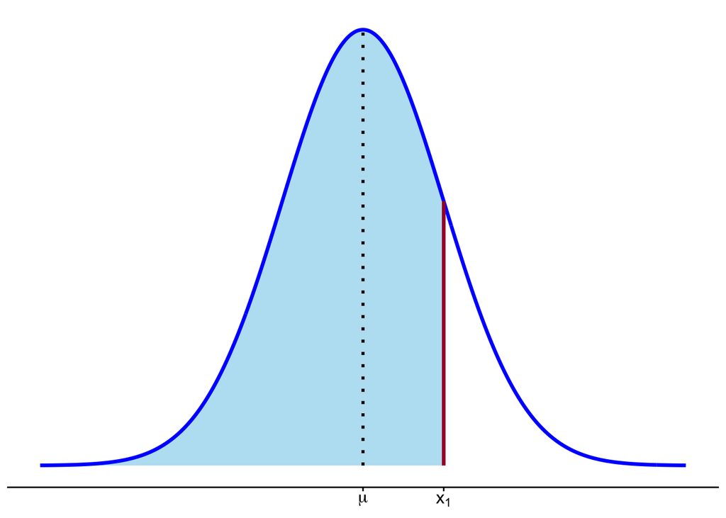

The plot below illustrates the probabilities $P(x_1 \leqslant X \leqslant x_2)$, $P(x_1 \leqslant X < x_2)$, $P(x_1 < X \leqslant x_2)$, or $P(x_1 < X < x_2)$.

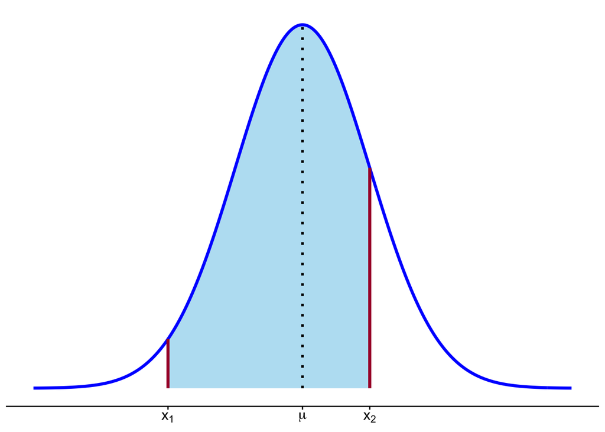

The plot below shows the probabilities $P(X \leqslant x_1 \text{ or } X \geqslant x_2)$, $P(X \leqslant x_1 \text{ or } X > 2)$, $P(X < x_1 \text{ or } X \geqslant x_2)$, or $P(X < x_1 \text{ or } X > x_2)$.

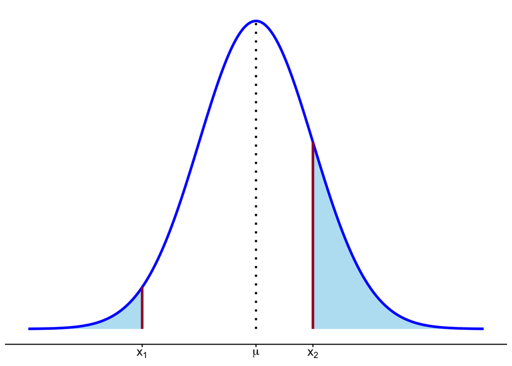

## Section 6.1 Examples

**TipExample 1**

**Question**

Consider the random variable $X$ where $X =$ number of stars given by a randomly selected book reviewer. The probability distribution of the number of stars is shown below. Estimate the probability that a randomly selected reviewer gave a given book a three-star rating.

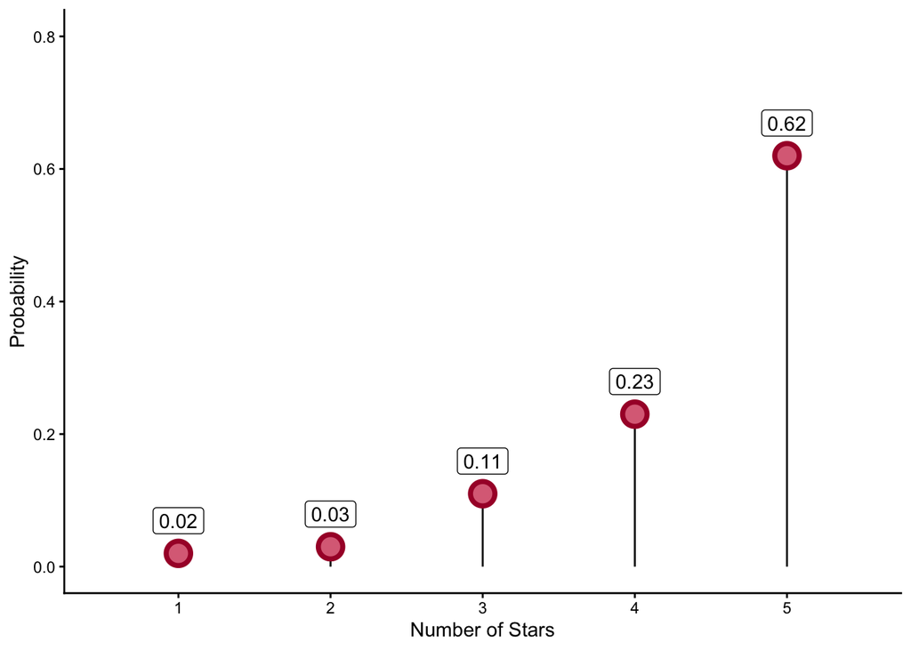

**Answer**

The probability value for three-star rating is 0.11.

**TipExample 2**

**Question**

When an *unfair coin* is tossed, the probability that it lands on heads is 80%, and the probability that it lands on tails is 20%. Let $H$ to mean heads and $T$ tails.

1. List all possible outcomes when flipping two unfair coins.
2. Are the coin tosses independent of one another? Why?
3. Complete the table below.

|  | $P(HH)$ | $P(HT)$ | $P(TH)$ | $P(TT)$ | **Total** |
| --- | --- | --- | --- | --- | --- |
| **Probability** |  |  |  |  |  |

4. Let $X =$ number of coins that land on heads out of two tosses, complete the following probability distribution table.

| $X$ | **0** | **1** | **2** | **Total** |
| --- | --- | --- | --- | --- |
| $P(X)$ |  |  |  |  |

**Answer**

1. There are 4 distinct outcomes you can get from flipping 2 coins.
   $$\{ HH, HT, TH, HH \}$$
2. The coin tosses are independent of each other, because the outcome of a toss does not depend on the outcome of the previous toss.
3. We need to first calculate the following probabilities. Assuming that the coin tosses are independent events. Then
   $$\begin{align}
   P(HH) &= P(H) \cdot P(H) = 0.8 \cdot 0.8 = 0.64\\
   P(HT) &= P(H) \cdot P(T) = 0.8 \cdot 0.2 = 0.16\\
   P(TH) &= P(T) \cdot P(H) = 0.2 \cdot 0.8 = 0.16\\
   P(TT) &= P(T) \cdot P(T) = 0.2 \cdot 0.2 = 0.04
   \end{align}$$
   Finally, adding these probability together, we have
   $$P(HH) + P(HT) + P(TH) + P(TT) = 0.64 + 0.16 + 0.16 + 0.04 = 1$$
4. First observe that
   $$\begin{align}
   X &= \text{event with 0 heads} = \{ TT \},\\
   X &= \text{event with 1 heads} = \{ HT, TH \},\\
   X &= \text{event with 2 heads} = \{ HH \}
   \end{align}$$
   Therefore
   $$\begin{align}
   P(X = 0) &= 0.04,\\
   P(X = 1) &= P(HT) + P(TH) = 0.16 + 0.16 = 0.32,\\
   P(X = 2) &= P(HH) = 0.64
   \end{align}$$
   And the sum is
   $$P(X = 0) + P(X = 1) + P(X = 2) = 0.04 + 0.32 + 0.64 = 1.$$

**TipExample 3**

**Question**

1. What is the minimum wait time at the coffee shop?
2. What is the maximum wait time at the coffee shop?
3. Based on the plot, approximately what is the probability that someone will wait between 0 and 2 minutes?

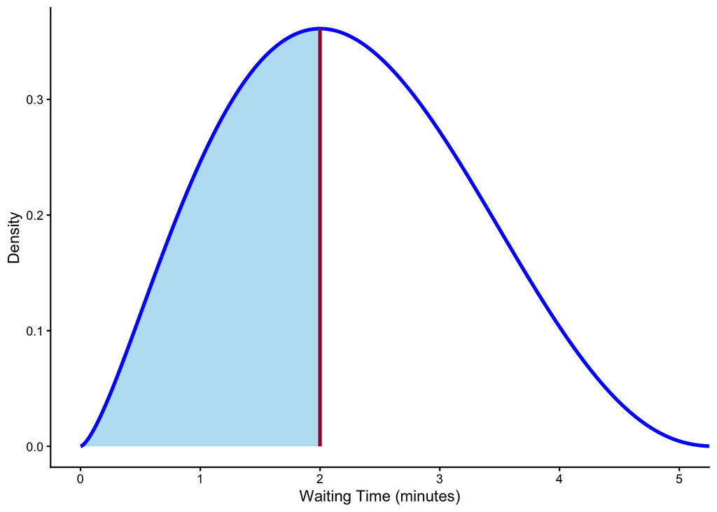

**Answer**

a. The minimum wait time is 0 minutes.  
b. The maximum wait time is 5 minutes.  
c. The probability that someone will wait between 0 and 2 minutes is somewhat less than 50%.

[figure not shown]

**TipExample 4**

**Question**

A bus arrives at a certain stop every 12 minutes. The graph below shows the probability distribution for the continuous random variable $X =$ wait time before the bus arrives. This is an example of a **uniform distribution**, that is, a distribution in which every possibility for the random variable $X$ is equally likely. Use this distribution to find the probability of a wait time between 4 and 10 minutes.

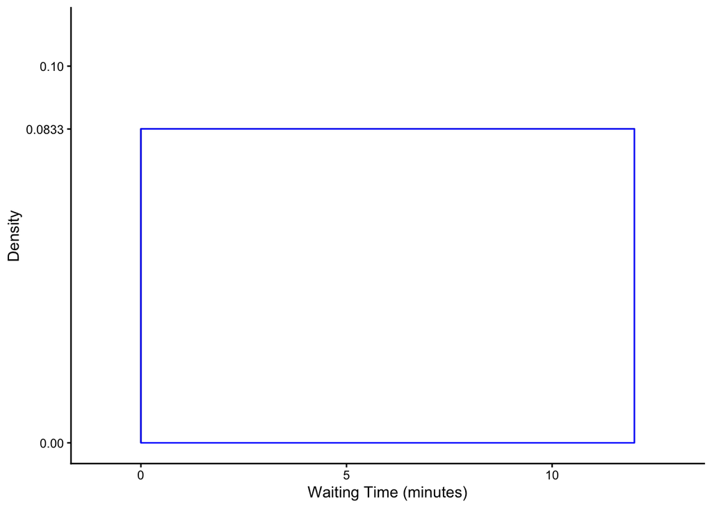

**Answer**

To find the probability of waiting between 4 and 10 minutes, we simply find the area of of the rectangle that is between 4 and 10. The width of the red rectangle is $10 - 4 = 6$ and its height is $0.0833$, so
$$P(4 \leqslant X \leqslant 10) = 6 \times 0.0833 = 0.4998 \approx 0.5$$

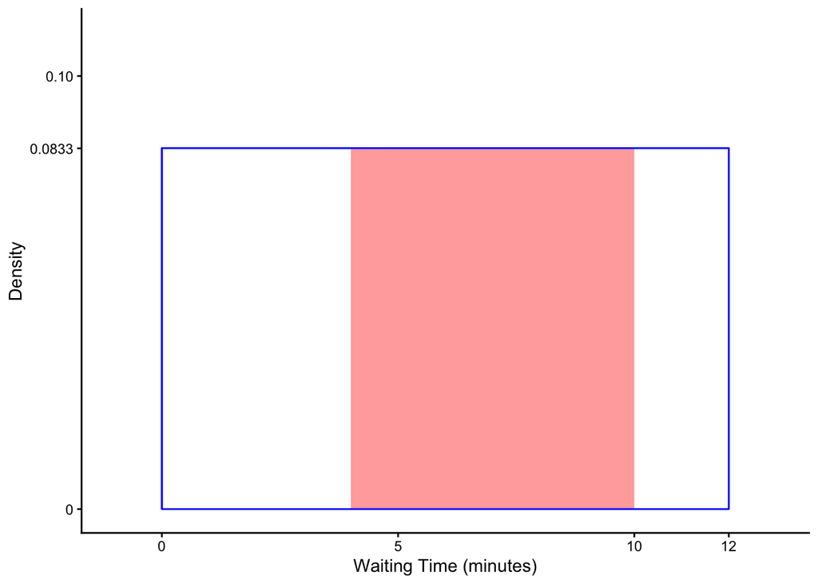

**TipExample 5**

**Question**

1. Is the length of the class a continuous or a discrete random variable?
2. Can a probability distribution (a table) be created for this random variable?
3. The probability density function for the random variable of class time is given below. What is the total area under the curve?
4. Determine the probability that the class runs over 75.5 minutes, i.e., $P(X \geqslant 75.5)$.

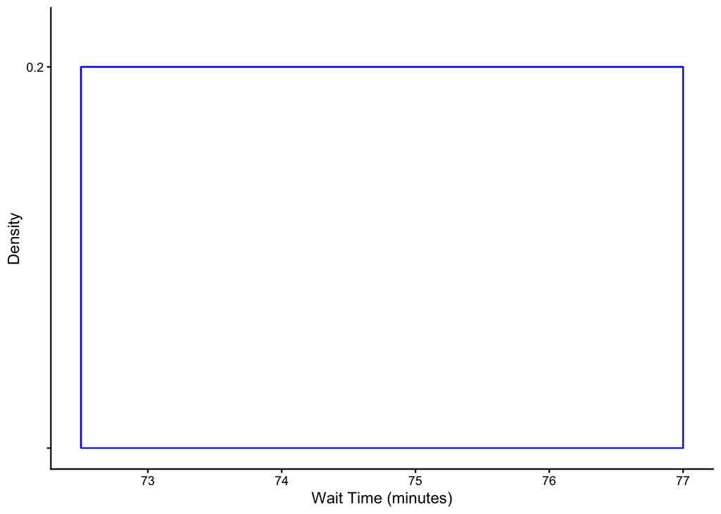

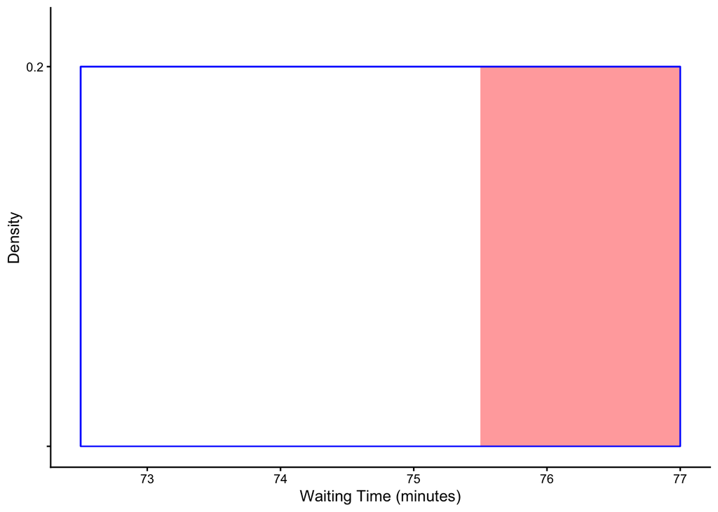

## Section 6.2. The Normal Distribution Model

**NoteNotation**

- Mean of a probability distribution: $\mu$ (“mu”)
- Standard deviation of a probability distribution: $\sigma$ (“sigma”)
- A normal distribution with mean $\mu$ and standard deviation $\sigma$: $N(\mu, \sigma)$.

**NoteThe Normal Distribution**

*Every* normal curve:

1. Is symmetric about its mean.
2. Has its peak at the mean.
3. Is bell-shaped.

All normal curves are characterized by two *parameters*: population mean $\mu$ and population standard deviation $\sigma$.

**TipExample 6.2.1.**

**Question**

Answer the following questions using the plot below.

1. What is the mean ($\mu$) of these normal distributions?
2. Approximate the standard deviation ($\sigma$) of these normal distributions.
3. What is the total area under each curve?

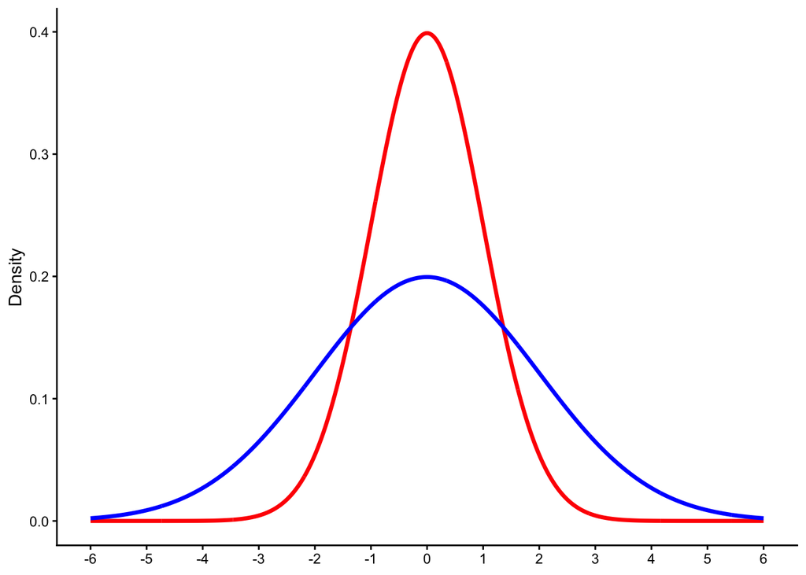

**Answer**

a. Both curves have a mean of $\mu = 0$.  
b. The standard deviation of the red curve is approximately 1, whereas the standard deviation of the blue curve is approximately 2.  
c. The total area under any normal curve is equal to 1.

**TipExample 6.2.2.**

**Question**

Answer the following questions using the plot below.

1. What is the mean ($\mu$) of each normal distribution?
2. Approximate the standard deviation ($\sigma$) of each normal distribution.
3. What is the total area under each curve?

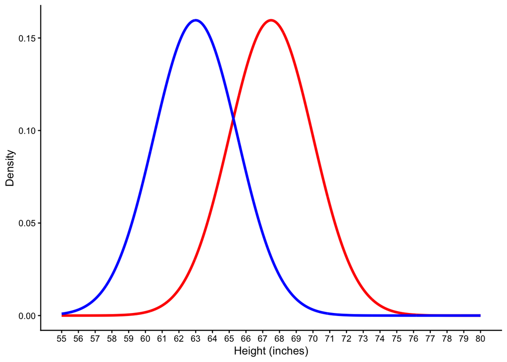

**NoteThe Normal Model and the Empirical Rule**

The normal model follows the _empirical rule:

1. **68%** of the data falls within **1** standard deviation of the mean.
2. **95%** of the data falls within **2** standard deviations of the mean.
3. **99.7%** of the data falls within **3** standard deviations of the mean.

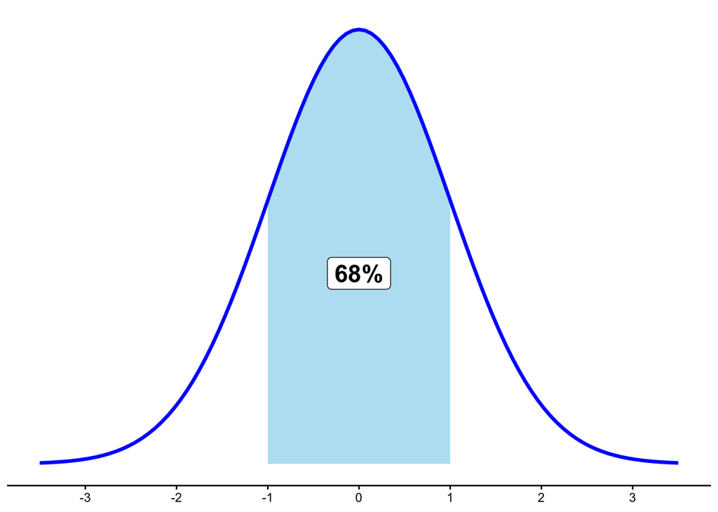

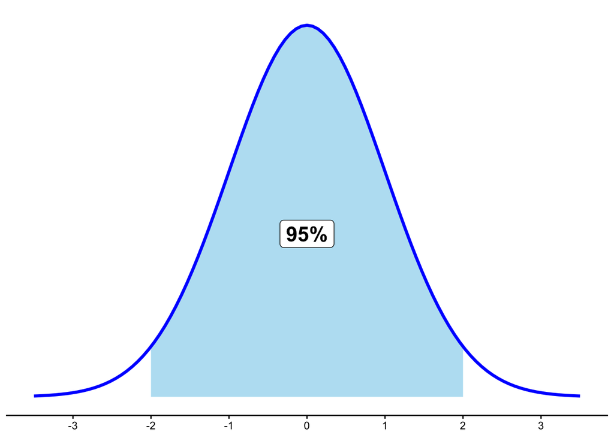

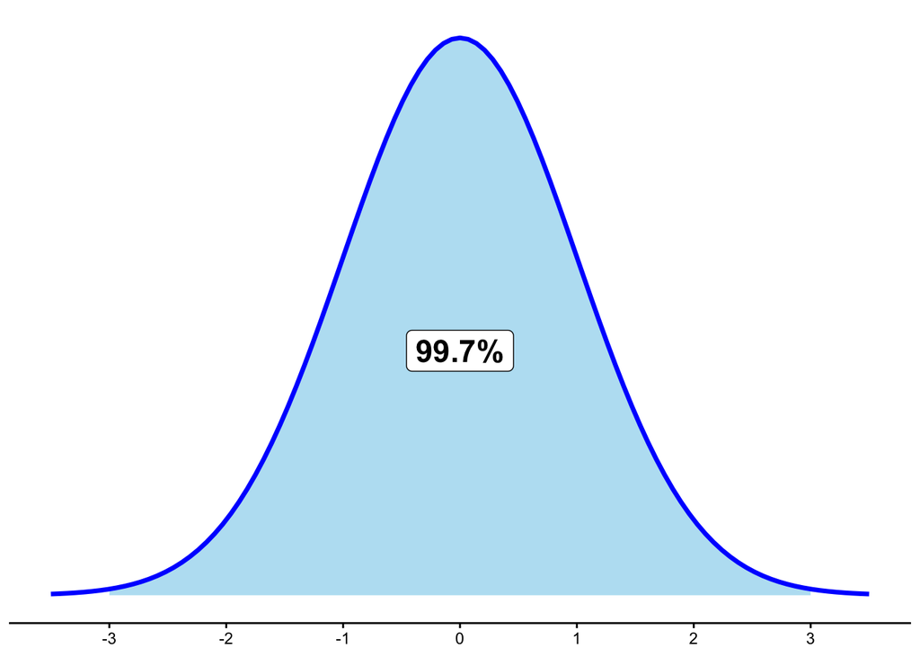

**TipExample 6.2.3.**

**Question**

The chest measurements of 18 year old male footballers is normally distributed with a mean of 95 cm and standard deviation of 8cm. Find the percentage of footballers with chest measurements between:

1. 87 cm and 103 cm
2. 103 cm and 111 cm

**Answer**

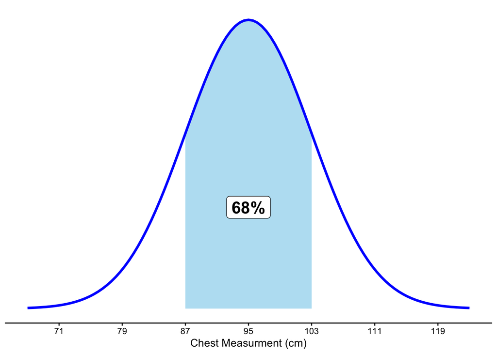

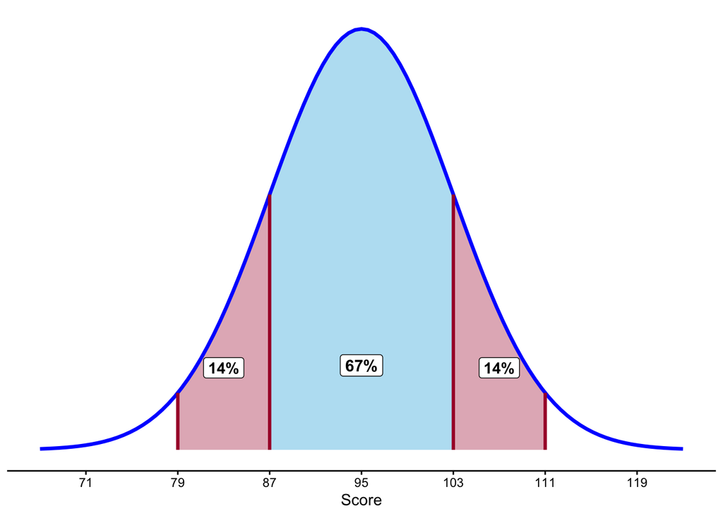

**NoteThe Standard Normal Distribution**

- The **standard normal distribution** is a normal distribution that has the mean of $\mu = 0$ and the standard deviation of $\sigma = 1$, and the total area under its density curve is 1.
- The standard normal distribution has $z$-scores on the $x$-axis.

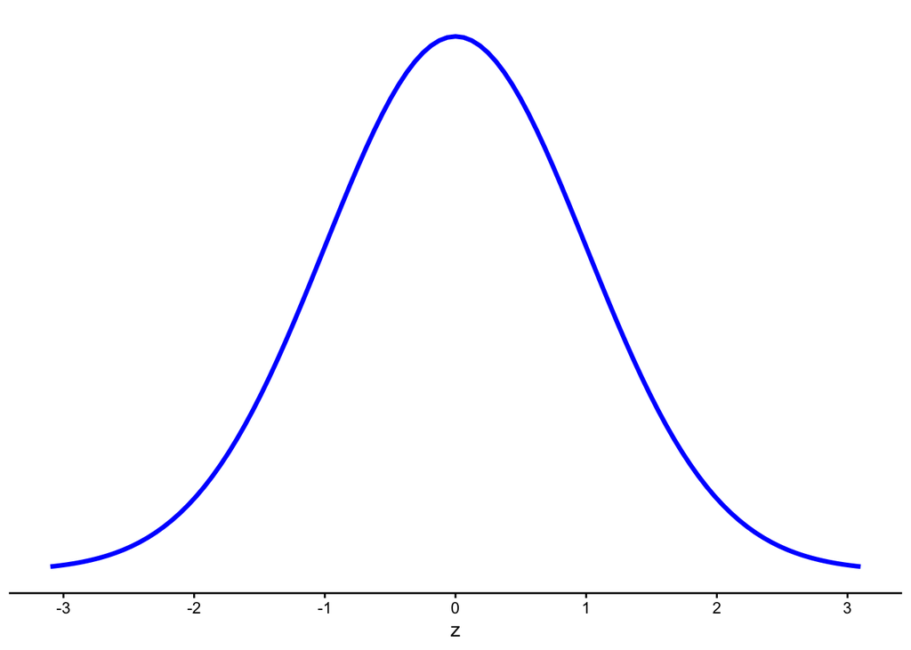

## Section 6.2 Examples